# Basic Parliament Plots

Zoe Meers

2024-05-19

## Introduction to `ggparliament`

`ggparliament` is a `ggplot2` extension for creating parliament plots. This `R` package allows users to plot different styles of legislatures. They are:

- semicircle layouts
- horseshoe parliaments
- opposing bench-style parliaments
- the classroom layout
- a circular parliament.

To plot a parliament in `ggparliament`, we start with a data frame containing the number of seats per political party. This package comes with recent election results from the UK, Australia, the United Sates, Russia, and Germany. `election_data` also provides party colour, abbreviated and full versions of the party name, as well as election returns over several election cycles.

### Semicircle Parliament

To plot a semicircle legislature, run the following commands:

1. Gather some election results.

```r
us_rep <- election_data %>%
    filter(country == "USA" &
               year == 2016 &
               house == "Representatives")
head(us_rep)
```

```
#>   year country           house party_long party_short seats government  colour
#> 1 2016     USA Representatives Republican         GOP   241          1 #E81B23
#> 2 2016     USA Representatives Democratic         Dem   194          0 #3333FF
```

2. Input the data into `ggparliament::parliament_data`.

This function unravels election results by party to individual seats. Users must define the input data frame, the type of legislature, the number of rows in the legislature, and a numeric variable which expands the number of seats to the total number of members in the legislature.

```r
us_house_semicircle <- parliament_data(election_data = us_rep,
                                       type = "semicircle",
                                       parl_rows = 10,
                                       party_seats = us_rep$seats)
head(us_house_semicircle)
```

```
#>     year country           house party_long party_short seats government
#> 1   2016     USA Representatives Republican         GOP   241          1
#> 1.1 2016     USA Representatives Republican         GOP   241          1
#> 1.2 2016     USA Representatives Republican         GOP   241          1
#> 1.3 2016     USA Representatives Republican         GOP   241          1
#> 1.4 2016     USA Representatives Republican         GOP   241          1
#> 1.5 2016     USA Representatives Republican         GOP   241          1
#>      colour         x            y row    theta
#> 1   #E81B23 -2.000000 2.449294e-16  10 3.141593
#> 1.1 #E81B23 -1.888889 2.313222e-16   9 3.141593
#> 1.2 #E81B23 -1.777778 2.177150e-16   8 3.141593
#> 1.3 #E81B23 -1.666667 2.041078e-16   7 3.141593
#> 1.4 #E81B23 -1.555556 1.905006e-16   6 3.141593
#> 1.5 #E81B23 -1.444444 1.768934e-16   5 3.141593
```

The resulting data frame returns the x and y coordinates of each individual seat for a 10-row semicircle parliament.

3. Plot the data in ggparliament

The user can take this data frame and plot by the x and y coordinates using `geom_parliament_seats()`.

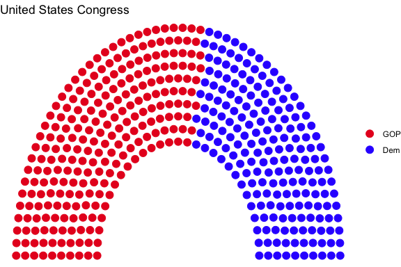

```r
us <- ggplot(us_house_semicircle, aes(x = x,
                                      y = y,
                                      colour = party_short)) +
    geom_parliament_seats() +
    theme_ggparliament() +
    labs(colour = NULL,
         title = "United States Congress") +
    scale_colour_manual(values = us_house_semicircle$colour,
                        limits = us_house_semicircle$party_short)

us
```

Other parliaments are plotted using the same method. The type of parliament should change - i.e, for a horseshoe parliament, specify horseshoe and so on. There are five types - “semicircle”, “horseshoe”, “opposing_benches”, “classroom” and “circle”.

### Horsehoe Parliament

```r
australia <- election_data %>%
    filter(country == "Australia" &
               house == "Representatives" &
               year == 2016)

australia_horseshoe <- parliament_data(election_data = australia,
                                       party_seats = australia$seats,
                                       parl_rows = 4,
                                       type = "horseshoe")
```

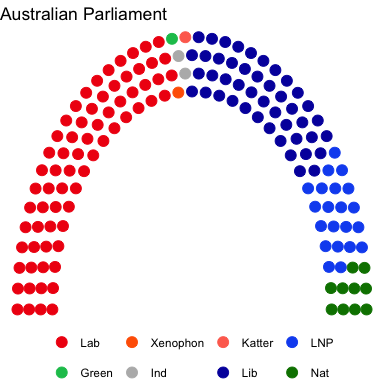

```r
au <- ggplot(australia_horseshoe, aes(x = x,
                                      y = y,
                                      colour = party_short)) +
    geom_parliament_seats() +
    theme_ggparliament() +
    labs(colour = NULL,
         title = "Australian Parliament") +
    scale_colour_manual(values = australia$colour,
                        limits = australia$party_short) +
    theme(legend.position = 'bottom')

au
```

### Opposing Benches Parliament

The opposing bench style of parliament calls for a variable to split the left and right bench. Using the ggparliament election data, we split on the government column which is a binary variable.

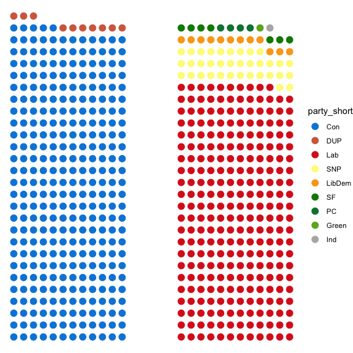

```r
#get the data for the last election
uk_data <- election_data %>%
  filter(country == "UK") %>%
  filter(year == 2017) %>% #parliament_data() can be called in a dplyr chain.
  parliament_data(election_data = .,
                  party_seats = .$seats,
                  #need to include grouping for opposing benches by definition
                  group = .$government,
                  parl_rows = 12,
                  type = "opposing_benches")

#plot it
uk <- ggplot(uk_data, aes(x, y, colour = party_short)) +
  scale_colour_manual(values = uk_data$colour, limits = uk_data$party_short) +
  geom_parliament_seats() +
  theme_ggparliament()

uk
```

### Classroom parliament

```r
russia_classroom <- election_data %>%
  filter(country == "Russia" &
    house == "Duma" &
    year == 2016) %>%
  parliament_data(election_data = .,
                  party_seats = .$seats,
                  parl_rows = 11,
                  type = "classroom")
```

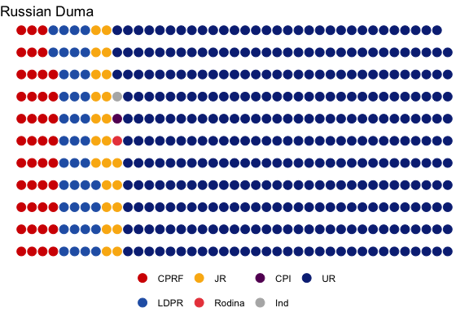

```r
rus <- ggplot(russia_classroom, aes(x,
                                    y,
                                    colour = party_short)) +
  geom_parliament_seats() +
  theme_ggparliament() +
  labs(colour = NULL,
    title = "Russian Duma") +
  scale_colour_manual(values = russia_classroom$colour,
    limits = russia_classroom$party_short) +
  theme(legend.position = "bottom")

rus
```

### Circle parliament

There are few national legislative bodies that use a circular parliament. Given that this vignette is primarily to explain how the process works, we are re-using the Russian election returns for this example.

```r
russia_circle <- election_data %>%
  filter(country == "Russia" &
    house == "Duma" &
    year == 2016) %>%
  parliament_data(election_data = .,
    party_seats = .$seats,
    parl_rows = 11,
    type = "circle")
```

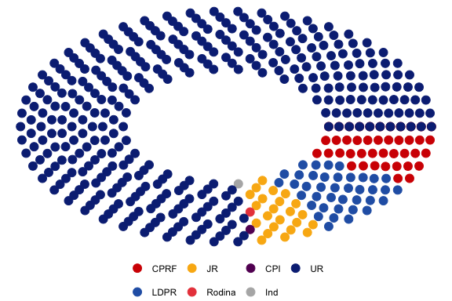

```r
russia_circle_example <- ggplot(russia_circle, aes(x,
                                                   y,
                                                   colour = party_short)) +
  geom_parliament_seats() +
  theme_ggparliament() +
  scale_colour_manual(
    values = russia_circle$colour,
    limits = russia_circle$party_short) +
  labs(colour = NULL) +
  theme(legend.position = "bottom")

russia_circle_example
```

Though not suggested, data can also be plotted simply from a vector of the parties winning seats as below.

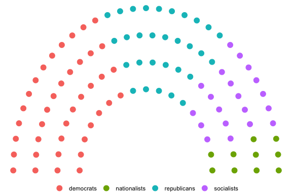

```r
#a made up example of a vector of seats
seats <- c(rep("democrats", 40),
           rep("republicans", 30),
           rep("socialists", 20),
           rep("nationalists", 10))

made_up_layout <- parliament_data(election_data = NULL,
    party_seats = as.numeric(table(seats)),
    parl_rows = 4,
    type = "semicircle")

made_up_layout$party = seats

plot <- ggplot(made_up_layout, aes(x,
                                   y,
                                   colour = party)) +
    geom_parliament_seats() +
    theme_ggparliament() +
    labs(colour = NULL) +
    theme(legend.position = "bottom")

plot
```

You can also create a data frame in `R` and plot your results.

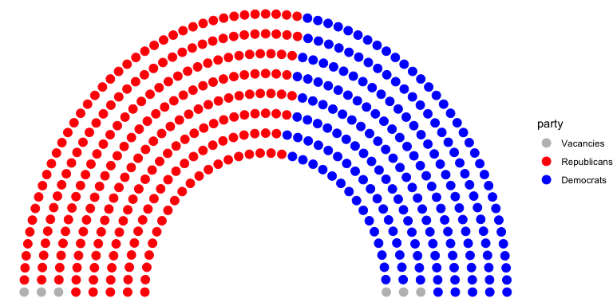

```r
house_of_reps <- data.frame(
  party = c("Vacancies","Republicans", "Democrats", "Vacancies"),
  seats = c(3, 236, 193, 3),
  color = c("gray", "red", "blue", "gray")
)
house_of_reps <- house_of_reps %>%
  mutate(party = as.character(party),
         color = as.character(color)) %>%
  parliament_data(election_data = .,
                            parl_rows = 8,
                            party_seats = .$seats,
                            type = 'semicircle')
ggplot(data = house_of_reps) +
  geom_parliament_seats(aes(x = x,  y = y, color = party)) +
  theme_ggparliament() +
  scale_color_manual(values = house_of_reps$color,
                     limits = house_of_reps$party)
```